# **`3. Probability and Statistics`**

### **`3.1 R Functions for Probability Distributions`**

R’s `stats` package provides probability density/mass function (pdf/pmf), cumulative distribution function (cdf), quantile function and (pseudo-) random number generator for a wide range of common probability distributions. One can call these built-in functions through prefixing a specific distribution name (abbreviation) by `d` for pdf/pmf, `p` for cdf, `q` for quantile, and `r` for random draws. For a comprehensive introduction to R’s probability functions, see [CRAN Task View: Probability Distributions](https://cran.r-project.org/web/views/Distributions.html).

```r
# pmf of Binomial(5,0.7) evaluated at 3
dbinom(3, size = 5, prob = 0.7)
```

```
## [1] 0.3087
```

```r
# pdf of N(0,1) evaluated at (0, .25, .5, .75, 1)
dnorm(seq(from = 0, to = 1, length = 5), mean = 0, sd = 1)
```

```
## [1] 0.3989423 0.3866681 0.3520653 0.3011374 0.2419707
```

```r
# 99% percentile of F(2,5)
qf(0.01, 2, 5, lower.tail = F)
```

```
## [1] 13.27393
```

```r
# probability of two-sided t(3) tails
2*pt(-2.43, df = 3)
```

```
## [1] 0.09333003
```

```r
# 5 random draws from N(0,1)
rnorm(5, mean = 0, sd = 1)
```

```
## [1]  0.1312570 -0.4719662  0.6819025  0.5062684  1.3041752
```

### **`3.2 Simulation`**

It is often important to draw random (correlated) samples from a multivariate distribution. For multivariate normal distribution, one can use the `mvrnorm()` function in the `MASS` package.

```r
# random draws from MVN((0,0),[1,0.5;0.5,1])
library(MASS)
mu <- c(0, 0)
sigma <- diag(2)/2 + .5*matrix(1, nrow = 2, ncol = 2)
mvrnorm(n = 5, mu, sigma)
```

```
##             [,1]       [,2]
## [1,] -0.97254539 -0.8933780
## [2,]  1.07416758  2.4576027
## [3,] -0.07885519  0.7541158
## [4,] -0.75422959 -0.6335910
## [5,] -1.98821607 -0.5757980
```

To draw random samples from a general multivariate distribution, one can consider the `genCorGen()` function in the `simstudy` package[^1]

```r
# random draws from Unif[0,1] and Unif[-1,1] with correlation 0.5
library(data.table)
library(simstudy)
genCorGen(n = 5, nvars = 2, params1 = c(0, -1), params2 = c(1, 1),
          dist = "uniform", corMatrix = sigma, wide = T)
```

```
##    id           V1          V2
## 1:  1 0.4410730850 -0.65440759
## 2:  2 0.0004750183  0.07851426
## 3:  3 0.3393446413 -0.05525821
## 4:  4 0.4936230753  0.47370041
## 5:  5 0.2923807488  0.25564335
```

When simulating random numbers, it is often desirable to set a random number seed (an integer) to ensure reproducibility of the sequence of random numbers and the according simulation results. One can set random number seeds using the `set.seed()` function.

```r
set.seed(1)
rnorm(5, mean = 0, sd = 1)
```

```
## [1] -0.6264538  0.1836433 -0.8356286  1.5952808  0.3295078
```

```r
set.seed(1)
rnorm(5, mean = 0, sd = 1)
```

```
## [1] -0.6264538  0.1836433 -0.8356286  1.5952808  0.3295078
```

### **`3.3 Resampling Methods`**

The `sample()` function draws randomly from a specified vector of numbers allowing one to resample from existing observations.

```r
# sample with replacement
x <- c(1:10)
sample(x, size = 8, replace = T)
```

```
## [1]  3  2  7  4  8  5  8 10
```

```r
# sample without replacement, size <= length(x)
sample(x, size = 8, replace = F)
```

```
## [1]  4  7  8  2 10  1  9  6
```

```r
# sample with specified probability weights
Pr <- c(.5, .2, .2, .1, 0, 0, 0, 0, 0, 0)
sample(x, size = 8, replace = T, prob = Pr)
```

```
## [1] 1 1 2 1 1 3 1 1
```

```r
# do random permutation if the "size" argument is not specified and length(x) > 1
sample(x)
```

```
##  [1]  9  7 10  1  5  3  4  2  6  8
```

```r
# sample from 1:floor(x) if x is a scalar greater than 1
sample(5.5, size = 8, replace = T)
```

```
## [1] 3 5 1 3 5 4 3 5
```

More complicated sampling, such as rows from a data frame or a list, can be done by applying `sample()` to the indices.

```r
X <- cbind(seq(1:3), seq(1:3))
X[sample(1:nrow(X), size = 5, replace = T),]
```

```
##      [,1] [,2]
## [1,]    2    2
## [2,]    1    1
## [3,]    1    1
## [4,]    1    1
## [5,]    1    1
```

However, it is often more convenient and reliable to do resampling with the `boot()` function in the `boot` package. One can use `boot()` to generate R bootstrap replicates of a statistic applied to a data. The following code generates 500 bootstrap replicates to compute the 99% confidence interval (CI) of the sample median (statistic) based on a $\chi^2_{4}$ sample (data). By default, R does ordinary nonparametric bootstrap. For alternative resampling methods, check the `sim` argument of the `boot()` function.

```r
library(boot)
X <- rchisq(500, 4)
# define a median function with one argument for row index
f <- function(data, index) {median(data[index])}
median.boot <- boot(X, statistic = f, R = 500)
median.boot
```

```
##
## ORDINARY NONPARAMETRIC BOOTSTRAP
##
##
## Call:
## boot(data = X, statistic = f, R = 500)
##
##
## Bootstrap Statistics :
##     original      bias    std. error
## t1* 3.165811 -0.01859057   0.1550774
```

```r
str(median.boot)
```

```
## List of 11
##  $ t0       : num 3.17
##  $ t        : num [1:500, 1] 3 3.18 3.23 3.05 3.01 ...
##  $ R        : num 500
##  $ data     : num [1:500] 3.116 2.45 2.754 1.62 0.575 ...
##  $ seed     : int [1:626] 403 365 1492790388 -1629574902 -1817687082 -2080485428 -622102478 -1390801052 -1280540579 249411485 ...
##  $ statistic:function (data, index)
##   ..- attr(*, "srcref")=Class 'srcref'  atomic [1:8] 4 6 4 48 6 48 4 4
##   .. .. ..- attr(*, "srcfile")=Classes 'srcfilecopy', 'srcfile' <environment: 0x7fd9c8470180>
##  $ sim      : chr "ordinary"
##  $ call     : language boot(data = X, statistic = f, R = 500)
##  $ stype    : chr "i"
##  $ strata   : num [1:500] 1 1 1 1 1 1 1 1 1 1 ...
##  $ weights  : num [1:500] 0.002 0.002 0.002 0.002 0.002 0.002 0.002 0.002 0.002 0.002 ...
##  - attr(*, "class")= chr "boot"
##  - attr(*, "boot_type")= chr "boot"
```

```r
# take a look at the first couple of bootstrap replicates
head(median.boot$t)
```

```
##          [,1]
## [1,] 2.998490
## [2,] 3.181002
## [3,] 3.228184
## [4,] 3.045752
## [5,] 3.012036
## [6,] 3.203740
```

Then the bootstrap CI can be easily obtained using the `boot.ci()` function.

```r
boot.ci(median.boot, conf = 0.99)
```

```
## BOOTSTRAP CONFIDENCE INTERVAL CALCULATIONS
## Based on 500 bootstrap replicates
##
## CALL :
## boot.ci(boot.out = median.boot, conf = 0.99)
##
## Intervals :
## Level      Normal              Basic
## 99%   ( 2.785,  3.584 )   ( 2.645,  3.553 )
##
## Level     Percentile            BCa
## 99%   ( 2.779,  3.686 )   ( 2.779,  3.714 )
## Calculations and Intervals on Original Scale
## Some basic intervals may be unstable
## Some percentile intervals may be unstable
## Some BCa intervals may be unstable
```

### **`3.4 Empirical Distributions`**

With a set of observations, one can compute the empirical cdf using the `ecdf()` function.

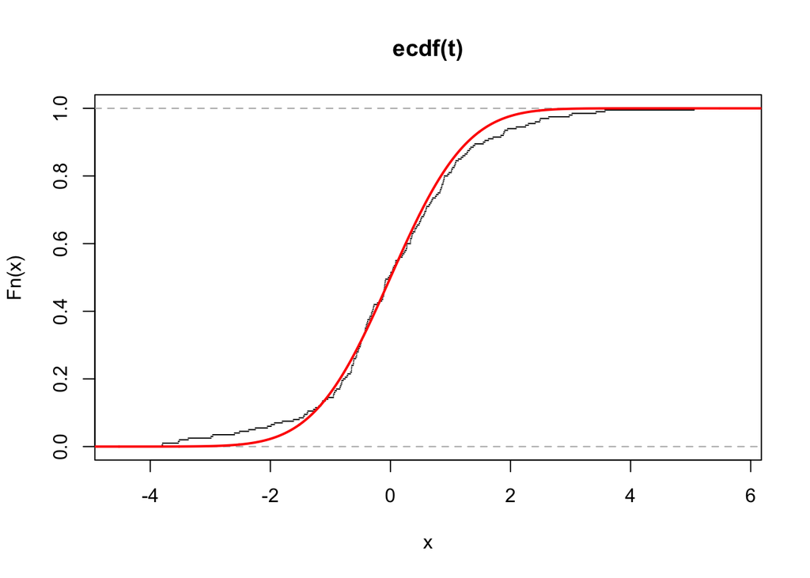

```r
# compute and plot the empirical cdf, compare it with the cdf of N(0,1)
t <- rt(200, df = 3)
plot(ecdf(t), do.points = F, verticals = F)
z <- seq(-7, 7, .01)
lines(z, pnorm(z, 0, 1), lwd = 2, col = "red")
```

Similarly, one can also compute and plot the kernel density function using the `density()` function along with the histogram.

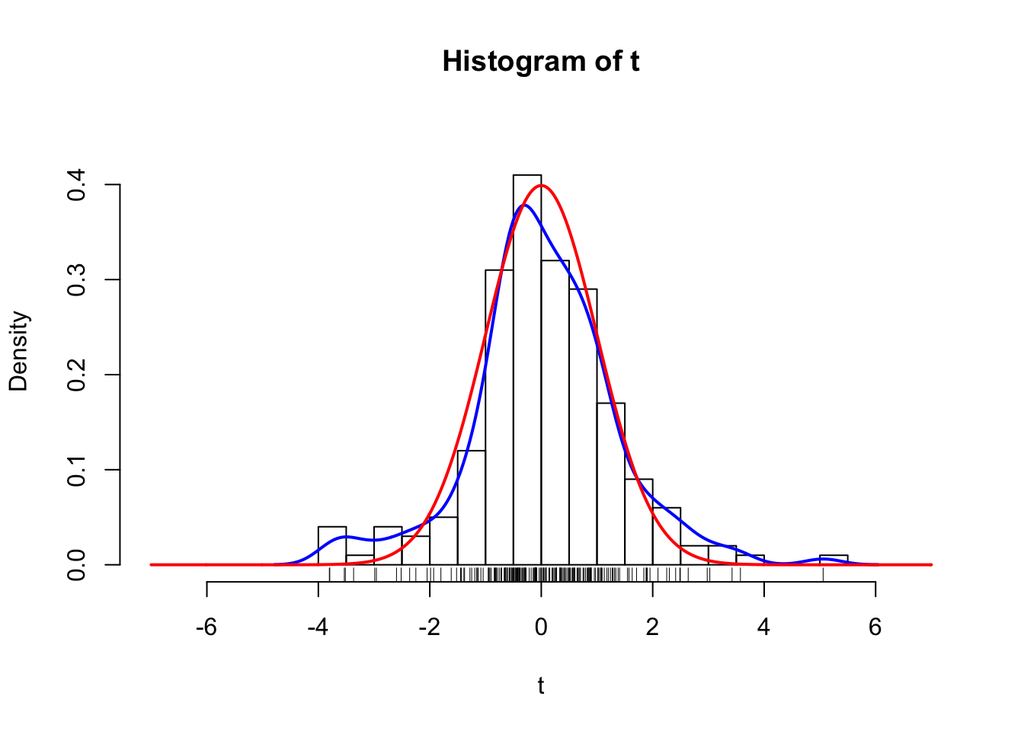

```r
# histogram
hist(t, freq = F, breaks = 20, xlim = c(-7, 7), ylim = c(0,0.45))
# empirical density
lines(density(t), col = "blue", lwd = 2)
# N(0,1) density
lines(z, dnorm(z, 0, 1), lwd = 2, col = "red")
# show actual data points
rug(t)
```

A better way to examine the distribution of data is to draw a QQ plot. One can use the `qqnorm()` function to create a normal QQ plot, and use the `qqline()` function to add a line for a “theoretical”, by default normal, QQ plot which passes through (by default) the first and third quantiles of the data.

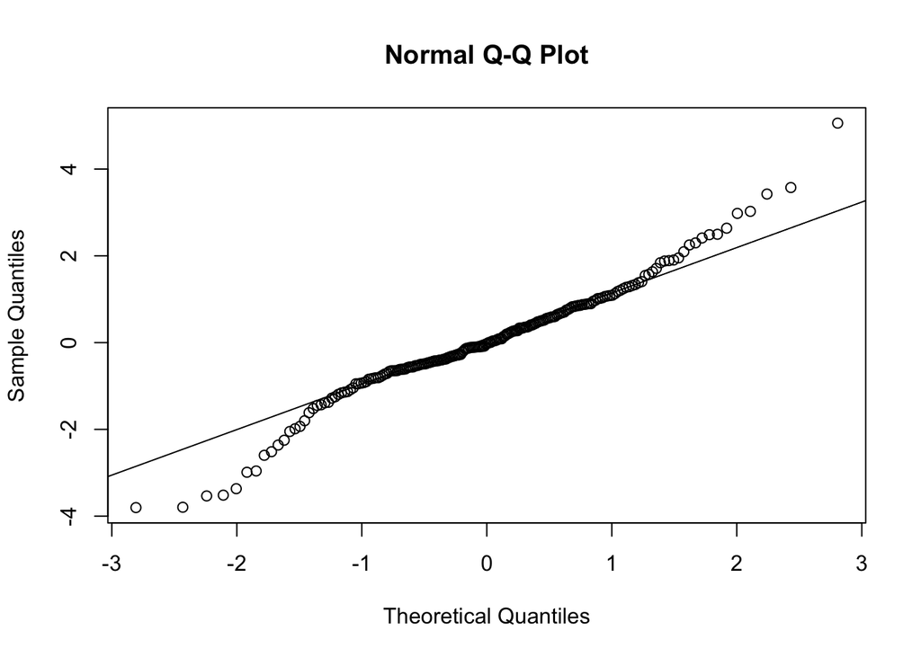

```r
qqnorm(t)
qqline(t)
```

QQ plot can also be drawn against a (arbitrary) generated distribution using the `ppoints()` function.

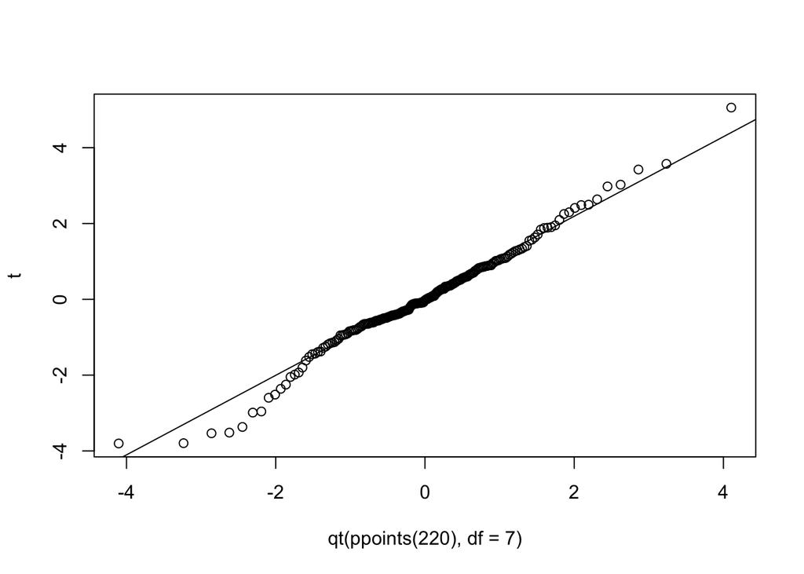

```r
qqplot(qt(ppoints(220), df = 7), t)
qqline(t)
```

### **`3.5 Tests`**

One can perform a wide variety of statistical tests in R. Here let’s use the `t.test()` function for one/two/paired sample t-test to show how to conduct a statistical test and retrieve the test results using R.

```r
X <- rnorm(100)
# one-sample t-test with confidence level = 99%
t.test(X, mu = 1, conf.level = .99)
```

```
##
##  One Sample t-test
##
## data:  X
## t = -10.318, df = 99, p-value < 2.2e-16
## alternative hypothesis: true mean is not equal to 1
## 99 percent confidence interval:
##  -0.3075928  0.2230129
## sample estimates:
##   mean of x
## -0.04228992
```

```r
test1 <- t.test(X, mu = 1, conf.level = .99)
# return a list of t-test attributes
attributes(test1)
```

```
## $names
## [1] "statistic"   "parameter"   "p.value"     "conf.int"    "estimate"
## [6] "null.value"  "alternative" "method"      "data.name"
##
## $class
## [1] "htest"
```

```r
# retrieve p-value
test1$p.value
```

```
## [1] 2.21331e-17
```

```r
Y <- rnorm(100, 0, 2)
# two-sample, one-tailed t-test with H1: E(X) > E(Y), 'conf' is a shortcut for 'conf.level'
test2 <- t.test(X, Y, mu = 0, alt = "greater", conf = .9)
# retrieve CI
test2$conf.int
```

```
## [1] -0.3723134        Inf
## attr(,"conf.level")
## [1] 0.9
```

```r
# paired t-test
test3 <- t.test(X, Y, mu = 0, paired = T, conf = .9)
# retrieve t-statistic
test3$statistic
```

```
##          t
## -0.3793013
```

Many popular tests can be conducted in R using the class of `.test` functions. See also `wilcox.test()`, `chisq.test()`, `fisher.test()`, `shapiro.test()`, etc.

[^1]: One should first load the `data.table` package along with the `simstudy` package before using the `genCorGen()` function.